# Team Money Dataset

Pacific Federal Loan Campaign

Author

Charlie, Arya, Steven, Ryan (Team Money)

# 1 Introduction & Business Problem

Pacific Federal is a regional bank with more deposit customers than loan customers, and the retail banking division wants to convert more of those deposit holders into personal loan customers. The most recent campaign offered a personal loan to existing deposit holders and fewer than 10% accepted. That low conversion rate means the bank is spending outreach effort as well as their marketing budget on a lot of customers who never planned to take the loan, while potentially missing better leads inside the same base. We predict that on average, Pacific Federal Bank is missing out on around $1,432 in lost interest revenue from a missed qualified customer.

The decision-maker is the Chief Retail Officer, who needs to decide who to target in the next campaign round. A predictive model helps directly here. If we can estimate each customer’s probability of accepting a loan based on what the bank already knows about them, the CRO can rank the deposit base from most to least likely to accept and focus the budget on the top of that list. Even a moderate lift over the 9.6% baseline acceptance rate would translate into noticeably more loans booked at a similar campaign cost.

# 2 Data Summary & Cleaning

## 2.1 Summary Statistics

The dataset is a snapshot of Pacific Federal’s deposit customer base taken at the time of the most recent personal loan campaign. It contains 5,000 customer records with 14 columns covering demographics (Age, Experience, Education, Family, ZIP), financial details (Income, CCAvg, Mortgage), and existing product ownership (Securities Account, CD Account, Online banking, Credit Card). Each row is a single deposit customer. The outcome variable is Personal_Loan, a binary flag for whether the customer accepted the loan offer in the previous campaign.

The most important thing to flag up front is the class imbalance: only 9.6% of customers accepted, so any model we build needs to be evaluated with that imbalance in mind. The customer base skews older and more established, with a average age of 45 and 20 years of experience. Income ranges from 8k to 224k with a mean around 74k, which gives the models room to separate high- and low-likelihood customers. Existing product ownership at the bank is generally low: around 10% of customers hold a securities account, 6% hold a CD, and 29% carry a bank credit card.

On data quality, the dataset is in good shape. None of the 14 columns contain missing values. The only real issue we found is that 52 records, about 1% of the data, show negative years of professional experience, which is impossible and most likely either a data entry error or a placeholder for missing values. We treat these as bad data and drop them in the next section. Income has a long right tail with a handful of customers well above the mean, but those values look like genuine high earners rather than errors, so we keep them in the analysis.

Two patterns in the raw data jumped out during exploration and are worth flagging before the cleaning and modeling steps.

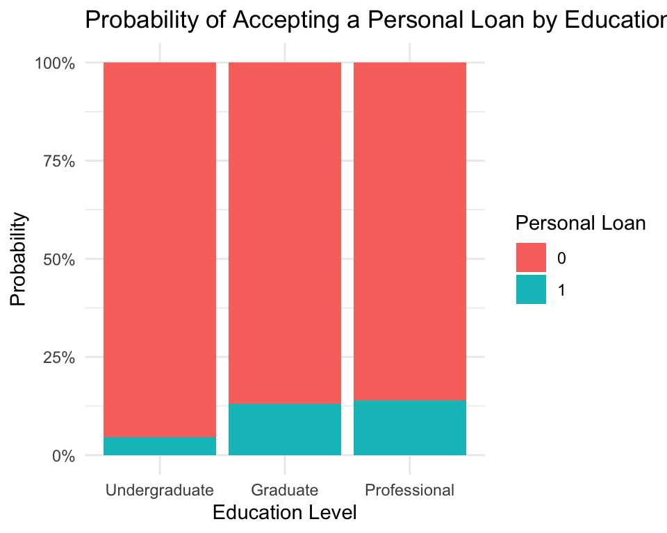

Graduate and Professional customers accept at roughly 14% versus 5% for Undergraduate, a sharp gap that flagged Education as a likely strong predictor.

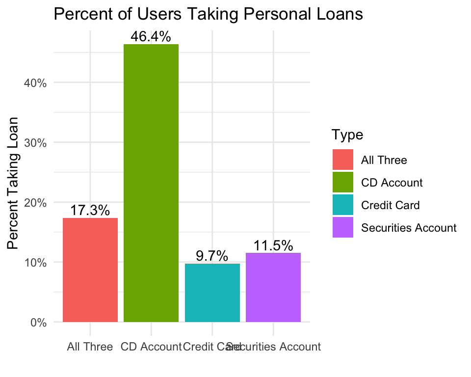

CD account holders accept at about 46%, nearly five times the 9.6% baseline, while credit card and securities holders sit close to baseline.

## 2.2 Data Cleaning

- Entries with negative years of experience removed
- Education changed to factor with labels in order to make visualizations with this predictor easier to interpret

# 3 Feature Engineering

Beyond the basic cleaning, we created four engineered features to capture relationships we thought the raw columns would not pick up on their own.

Income_Per_Family_Member came from the thought that household income tells us what the family earns but not how stretched that money is, so we divided income by family size to get a per-person figure. We expected a positive coefficient, but the lasso gave it a small negative one. That actually makes sense after the fact: for a fixed income, larger families have more financial need and may be more open to a loan.

Monthly_Income is just Income divided by 12. Most household financial decisions get framed in monthly terms, so we built a monthly version mainly to feed into the next feature.

Monthly_CC_Spending_to_Income puts credit card spending in context. Someone charging 2k a month on 200k of annual income is in a very different spot than someone charging the same on 40k, so dividing CCAvg by Monthly_Income gives a ratio that should pick up customers running close to their limits, who might be more receptive to a personal loan to consolidate.

A few things did not pay off. Monthly_Income on its own added nothing once Income was in the model, since a linear model treats scalar transformations as redundant. We also considered Mortgage in Model 1 but dropped it because it came out insignificant, and we dropped Age because it overlapped heavily with Experience.

# 4 Modeling & Results

## 4.1 Data Splitting

We split the cleaned data 80/20 into a training set used to fit the models and a test set used to evaluate them, with a fixed seed for reproducibility.

## 4.2 Model 1

Model 1 is a logistic regression using Experience, Income, Education, Family size, and CD account ownership as predictors. We picked this as the simple, interpretable baseline.

- Mortgage removed due to low significance
- Age removed due to likely high correlation with experience
- Initially started with a 90% cutoff because acceptance rate is around 10%
  - Lowered gradually until 0.63

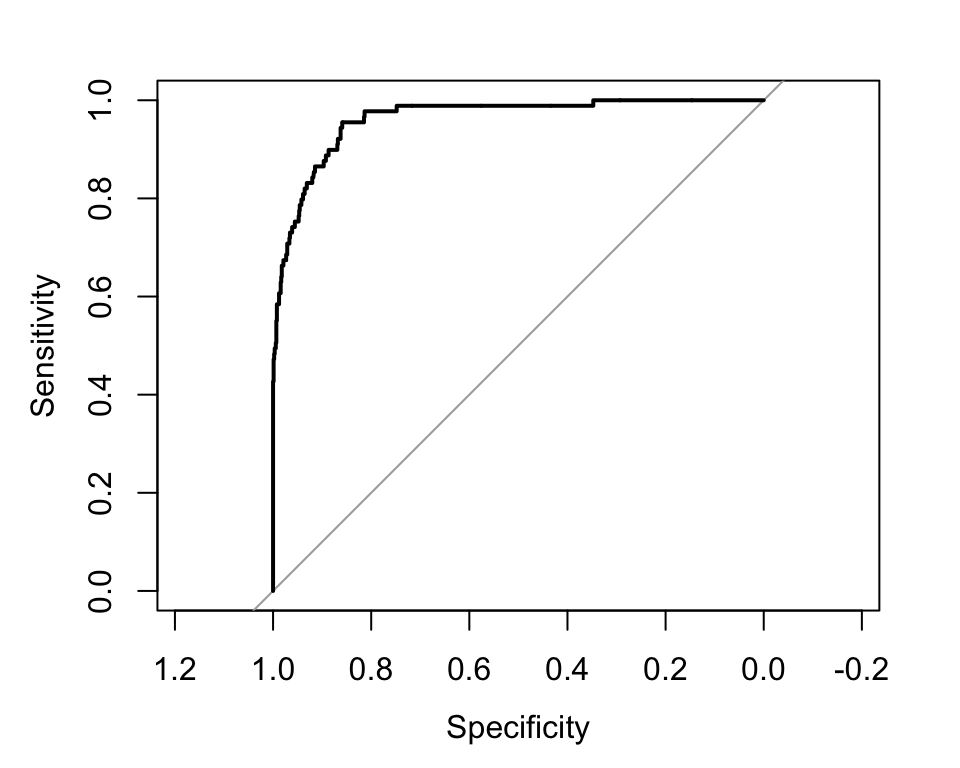

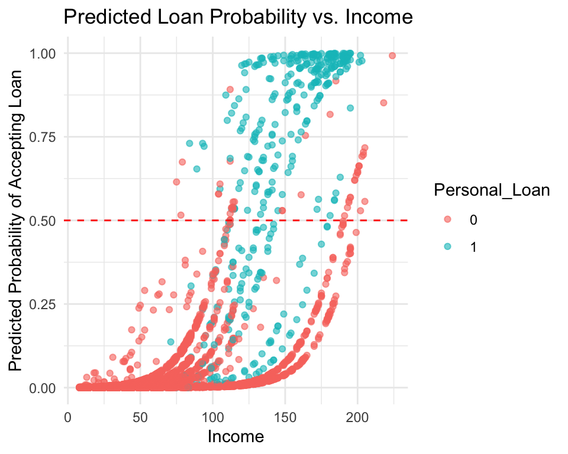

Predicted acceptance stays near zero until income hits about 100k and then rises sharply, which is what motivated the income_over_100k feature in Model 2.

## 4.3 Model 2

Model 2 is a lasso logistic regression fit on a wider feature set that includes our engineered variables. The lasso adds L1 regularization, which can shrink weak coefficients toward zero and acts as a form of variable selection.

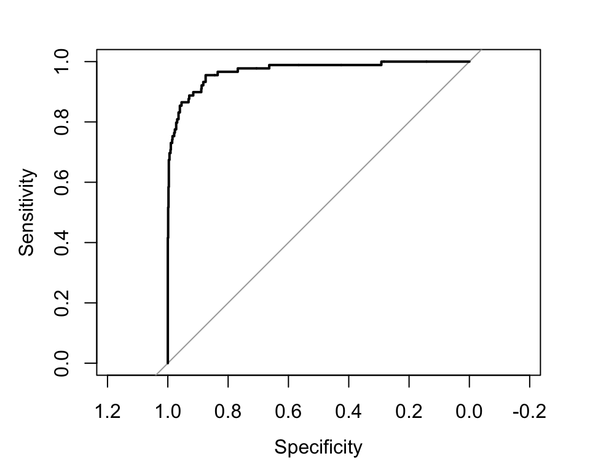

## 4.4 Model Evaluation & Comparison

We compared the two models on the metrics that matter for a classification problem with this kind of class imbalance:

| Metric | Model 1 (Logit) | Model 2 (Lasso) |
| --- | --- | --- |
| Cutoff | 0.63 | 0.6 |
| Accuracy | 95.2% | 96.5% |
| Sensitivity | 52.8% | 70.8% |
| Specificity | 99.3% | 99.0% |
| AUC | 0.962 | 0.970 |

Model 2 beats Model 1 on AUC and meaningfully on sensitivity, while giving up almost nothing on specificity. The accuracy numbers look similar, but accuracy is misleading here. With only 9.6% of customers accepting the loan, a model that predicts “no” for everyone would land around 90% accuracy and find zero takers. Sensitivity is the metric that matters because it measures how well the model identifies the customers the bank actually wants to find.

The cost of each error type also matters for picking a cutoff. A false positive means the bank reaches out to a customer who will not accept, and the cost is the marketing spend on that one contact. A false negative means the bank misses a customer who would have accepted, and the cost is the foregone interest income on a loan that does not get made. The interest on a personal loan over its lifetime is far larger than the cost of a single outreach contact, so the false negative cost dominates. That asymmetry is the reason we picked cutoffs on the lower end of what still kept specificity high, and it is the main reason we recommend Model 2 over Model 1.

# 5 Interpretation

Across both models, the predictors that mattered most were Income, Education level, and CD account ownership. In Model 1, Income was very significant (p < 2e-16) with a coefficient of 0.063, so every extra thousand dollars of income raises the chance a customer accepts the loan. Education had an even bigger effect: Graduate and Professional customers had log-odds about 3.6 higher than Undergraduate customers, holding everything else equal. CD_Account came in at 2.76, meaning customers who already have a CD are much more likely to take the loan too.

These results make sense for the business. Higher-income customers have room in their budget to take on a loan, and the bank can lend to them with less risk. More educated customers usually earn more over time and may be more used to working with debt products. CD holders are already invested with the bank, so they would be more open to a new product from the same place.

Experience came back as not significant in Model 1 (p ≈ 0.75). We had kept it in to capture career stage, but it did not add much once Income was in the model. Family was positive in Model 1 while Income_Per_Family_Member was negative in Model 2, which looked like a contradiction at first. The signs actually agree: for a given income, a bigger family means each person has less to work with, and those households are more open to a loan. The lasso also did not drop any predictors at the lambda that minimized CV error, so it acted like a regularized logit rather than doing real variable selection.

Even with the better sensitivity we get from Model 2, the model still misses close to 30% of the customers who actually took the loan, which is the most honest limitation of the work. A few others are worth flagging too. We only have one campaign of data, so we cannot say whether these patterns hold up over time or after the bank changes its product mix. We dropped ZIPCode, Online, and Securities_Account before modeling, and there might be signal in those. We also did not try interaction terms like Income times Education, which might have caught the nonlinearity above 100k more cleanly.

# 6 Conclusion & Recommendation

We recommend Model 2, the lasso. As shown in the evaluation section, it clearly beat Model 1 on the metrics that matter most for this problem without losing meaningful ground on specificity. Given the cost asymmetry between false positives and false negatives, we would actually push the cutoff slightly below 0.6 in production to capture a few more positives, since the extra outreach is cheaper to absorb than additional missed customers.

For the Chief Retail Officer, the takeaways come straight out of those coefficients. The first priority should be high-income deposit customers, especially anyone above 100k, since the income_over_100k indicator alone shifted the odds by a lot. Graduate and Professional degree customers convert at much higher rates than Undergraduate customers, so the campaign could lean into that audience in the messaging or product framing. CD account holders are a strong second group: they are already invested with the bank and the model treats them as warm leads. Family size also matters once income is controlled for, so households with several dependents and moderate incomes look more loan-receptive than the raw averages suggest. Customers who already carry a credit card look like cooler leads than they otherwise appear, so the outreach budget could go elsewhere.

If we had more time and data, there are a few things we would want to do. The first is to get an actual cost estimate from the marketing team for outreach versus a missed loan, then re-tune the cutoff to minimize expected dollar loss instead of picking a threshold by eye. The second is to try a tree-based model like random forest or XGBoost, since logit and lasso both assume linearity in the log-odds and acceptance probably has thresholds and interactions those models cannot pick up. We would also want to pull data from earlier campaigns to check whether the patterns hold up over time. Finally, if the bank has behavioral data like online banking activity or app logins, bringing that in would probably help with customers who do not have obvious income or CD signals.

# 7 Appendix: Model Outputs

The full raw output from each model is reproduced here for verification and reproducibility. The same R code that produced these objects ran in the body of the report; the prints below show the underlying detail behind the metrics cited in the Model Evaluation table.

## 7.1 Model 1: Logistic Regression Summary

```r
summary(logit1)
```

```
Call:
glm(formula = Personal_Loan ~ Experience + Income + Education +
    Family + CD_Account, family = binomial, data = loans_train)

Coefficients:
                        Estimate Std. Error z value
(Intercept)           -13.312497   0.630882 -21.101
Experience              0.002318   0.007390   0.314
Income                  0.062816   0.003013  20.849
EducationGraduate       3.583072   0.276693  12.950
EducationProfessional   3.643941   0.275452  13.229
Family                  0.658524   0.084720   7.773
CD_Account1             2.761693   0.269000  10.267
                                  Pr(>|z|)
(Intercept)           < 0.0000000000000002 ***
Experience                           0.754
Income                < 0.0000000000000002 ***
EducationGraduate     < 0.0000000000000002 ***
EducationProfessional < 0.0000000000000002 ***
Family                 0.00000000000000767 ***
CD_Account1           < 0.0000000000000002 ***
---
Signif. codes:  0 '***' 0.001 '**' 0.01 '*' 0.05 '.' 0.1 ' ' 1

(Dispersion parameter for binomial family taken to be 1)

    Null deviance: 2552.20  on 3957  degrees of freedom
Residual deviance:  986.05  on 3951  degrees of freedom
AIC: 1000.1

Number of Fisher Scoring iterations: 8
```

## 7.2 Model 1: Confusion Matrix (cutoff 0.63)

```r
cm
```

```
Confusion Matrix and Statistics

          Reference
Prediction   0   1
         0 895  42
         1   6  47

               Accuracy : 0.9515
                 95% CI : (0.9362, 0.964)
    No Information Rate : 0.9101
    P-Value [Acc > NIR] : 0.0000005509

                  Kappa : 0.6377

 Mcnemar's Test P-Value : 0.0000004376

            Sensitivity : 0.52809
            Specificity : 0.99334
         Pos Pred Value : 0.88679
         Neg Pred Value : 0.95518
             Prevalence : 0.08990
         Detection Rate : 0.04747
   Detection Prevalence : 0.05354
      Balanced Accuracy : 0.76072

       'Positive' Class : 1
```

## 7.3 Model 1: AUC

```r
auc(roc)
```

```
Area under the curve: 0.9621
```

## 7.4 Model 2: Lasso Coefficients at lambda.min

```r
coef(lasso_model, s = "lambda.min")
```

```
10 x 1 sparse Matrix of class "dgCMatrix"
                                 lambda.min
(Intercept)                   -11.101665409
Experience                      0.006182619
Income                          0.050573447
EducationGraduate               3.519013864
EducationProfessional           3.662988151
Monthly_CC_Spending_to_Income   2.193296248
CD_Account1                     3.064189459
Income_Per_Family_Member       -0.019512053
CreditCard1                    -0.913320546
income_over_100k                2.446561586
```

## 7.5 Model 2: Confusion Matrix (cutoff 0.6)

```r
cm_lasso
```

```
Confusion Matrix and Statistics

          Reference
Prediction   0   1
         0 892  26
         1   9  63

               Accuracy : 0.9646
                 95% CI : (0.9512, 0.9753)
    No Information Rate : 0.9101
    P-Value [Acc > NIR] : 0.00000000001196

                  Kappa : 0.7636

 Mcnemar's Test P-Value : 0.006841

            Sensitivity : 0.70787
            Specificity : 0.99001
         Pos Pred Value : 0.87500
         Neg Pred Value : 0.97168
             Prevalence : 0.08990
         Detection Rate : 0.06364
   Detection Prevalence : 0.07273
      Balanced Accuracy : 0.84894

       'Positive' Class : 1
```

## 7.6 Model 2: AUC

```r
auc(roc_lasso)
```

```
Area under the curve: 0.9696
```

## 7.7 How We Used AI

We used AI tools (ChatGPT and Claude) to consult on R syntax and Quarto formatting. All analysis, modeling decisions, and written interpretation are our own.